# Analyses of GSE223295

Profiling stress-triggered RNA condensation with photocatalytic proximity labeling.

Alexandre Kaizeler[^1] - alexandreafonso@gimm.pt<

02 October 2025

# Introduction

In this document, I present all analyses pertaining to the dataset **GSE223295**  
([NCBI GEO Link](https://www.ncbi.nlm.nih.gov/geo/query/acc.cgi?acc=GSE223295)),  
originally published by **Z. Ren, 2023**.

## Methodology

```r
# These are all the libraries I used throughout the analysis. Not all of them will be required on this guidebook
library(Rsubread)
library(limma)
library(edgeR)
library(DESeq2)
library(magrittr)
library(ggrepel)
library(tidyverse)
library(vsn)
library(ggplot2)
library(NMF)
library(biomaRt)
library(ggpubr)
library(factoextra)
library(ggfortify)
library(plotly)
library(reshape2)
library(fgsea)
library(msigdbr)
library(data.table)
library(colorspace)
library(readxl)


set.seed(1906)
```

## First Steps

```r
#This section here is to load up the genelenght file I will be using throughout the analyses.
genelength <- read.csv("~/Projects/StressGranules/SG_Transcriptome/RP_Data_2021/TrimmedSamples/alignment_STAR/TranscriptLenght.txt", header=T)

genelength <- subset(genelength, Ensembl.Canonical==1)
genelength <- subset(genelength, Gene.name!="")

genelength <- genelength %>%
  group_by(Gene.name) %>%
  slice(which.max(Transcript.length..including.UTRs.and.CDS.)) %>%
  ungroup()

genelength <- genelength[,-c(2,3)]
colnames(genelength) <- c("Length", "Gene")



#Get the table of read counts by indicating the path to the file. These files were obtained from the GEO dataset itself.

sg.read.counts_U2OS <- read_excel("~/Projects/StressGranules/SG_Transcriptome/CAP_Seq/GSE223295_U2OS_allcounts.xlsx")[,-1]
sg.read.counts_HEK <- read_excel("~/Projects/StressGranules/SG_Transcriptome/CAP_Seq/GSE223295_HEK293T_allcounts.xlsx")[,-1]

raw.read.counts <- merge(sg.read.counts_U2OS, sg.read.counts_HEK, by="geneId")


biomart <- fread("~/biomart.txt")[,-2]


colnames(raw.read.counts)[1] <- "ensembl_gene_id"
colnames(biomart) <- c("ensembl_gene_id", "hgnc_symbol")

eltable <- merge(raw.read.counts,biomart,by = "ensembl_gene_id", all= TRUE) #this creates a table with both ensemble ids and HGNC codes.

eltable <- subset(eltable, hgnc_symbol!="") #this removes reads that dont have a corresponding hgnc symbol.

eltable$ensembl_gene_id <- NULL

read.counts <- eltable %>% # If two gene ids resulted in the same gene name, this will sum up their counts
  group_by(hgnc_symbol) %>%
  summarise(across(everything(), sum, na.rm = TRUE))
read.counts <- as.data.frame(read.counts)

row.names(read.counts) <- read.counts$hgnc_symbol #changes rownames into hgnc symbols
read.counts$hgnc_symbol <- NULL #We no longer need this column, as we have the rownames.
```

## Extra Quality Control

Let’s check for sample complexity. It is possible that one or more samples have different complexity. In specific, I am going to check if enough reads have been obtained from every sample. If not, we should have a great bias to housekeeping genes. Another way to put it, is to say that even with all reads, we won’t obtain a great deal of different genes.

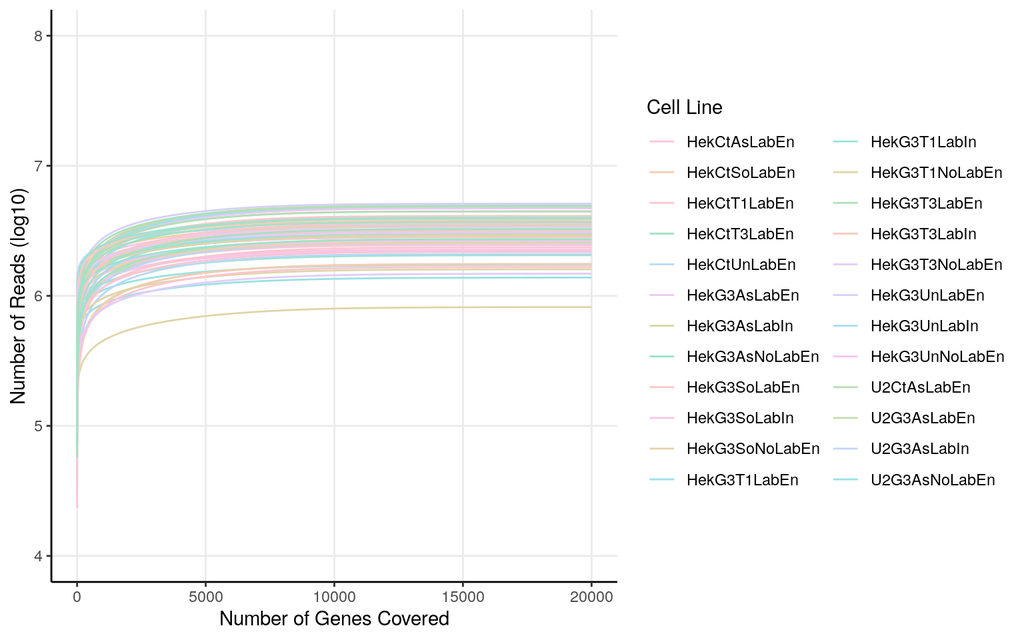

```r
# Define color palette
custom_palette <- qualitative_hcl(24, palette = "Pastel")
custom_palette <- sample(custom_palette, 24)

# Use SampleColouring from metadata
SampleColouring <- c(rep("U2G3AsLabEn",2), rep("U2G3AsLabIn",2),rep("U2G3AsNoLabEn",2),rep("U2CtAsLabEn",2),rep("HekG3AsLabEn",2), rep("HekG3AsLabIn",2),rep("HekG3AsNoLabEn",2),rep("HekCtAsLabEn",4),rep("HekG3UnLabEn",2), rep("HekG3UnLabIn",2),rep("HekG3UnNoLabEn",2),rep("HekCtUnLabEn",4),rep("HekG3SoLabEn",2), rep("HekG3SoLabIn",2),rep("HekG3SoNoLabEn",2),rep("HekCtSoLabEn",4),rep("HekG3T1LabEn",3), rep("HekG3T1LabIn",3),rep("HekG3T1NoLabEn",3),rep("HekCtT1LabEn",4),rep("HekG3T3LabEn",2), rep("HekG3T3LabIn",2),rep("HekG3T3NoLabEn",2),rep("HekCtT3LabEn",4))
# Build cumulative counts
final <- sapply(1:ncol(read.counts), function(i) {
  sort_vals <- read.counts[order(read.counts[, i], decreasing = TRUE), i]
  cumsum(sort_vals)
})
final <- as.data.frame(final)
colnames(final) <- colnames(read.counts)

# Melt and add gene position + sample info
finalmelt <- reshape2::melt(final, variable.name = "Sample")
finalmelt$genes <- rep(1:nrow(final), times = ncol(final))
finalmelt$SampleColouring <- rep(SampleColouring, each = nrow(final))

# Plot cumulative read coverage
ggplot(data = finalmelt, aes(x = genes, y = log10(value), group = Sample, color = SampleColouring)) +
  geom_line() +
  scale_color_manual(values = custom_palette, name = "Cell Line") +
  theme_bw() +
  xlab("Number of Genes Covered") +
  ylab("Number of Reads (log10)") +
  xlim(0, 20000) +
  ylim(4, 8) +
  theme(
    axis.line = element_line(colour = "black"),
    panel.grid.minor = element_blank(),
    panel.border = element_blank(),
    panel.background = element_blank()
  )
```

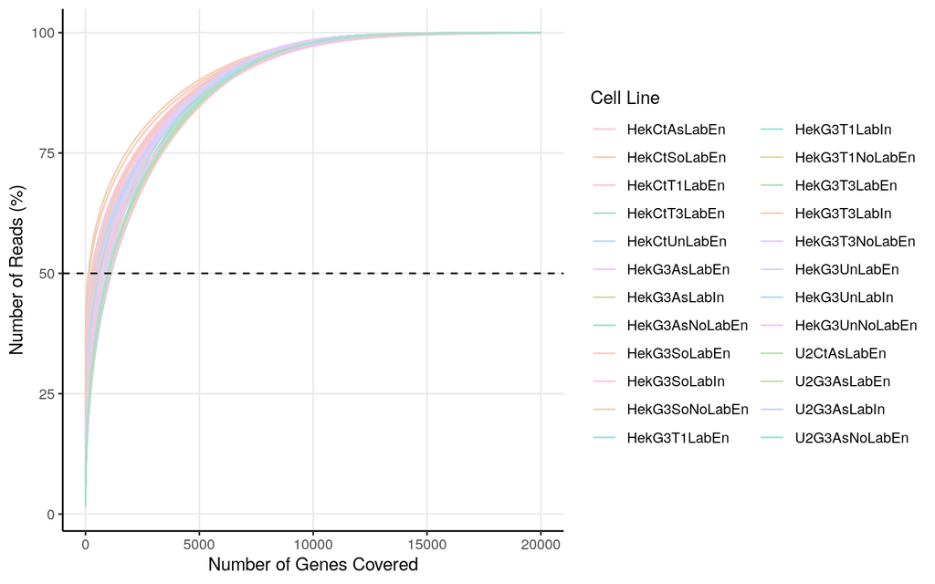

```r
# Create percentage-based plot
orderfinal <- subset(finalmelt, genes == max(finalmelt$genes))
trial <- merge(orderfinal[, c("Sample", "value")], finalmelt, by = "Sample", suffixes = c(".total", ".current"))
trial$percent <- (trial$value.current / trial$value.total) * 100
trial$SampleColouring <- rep(SampleColouring, each = nrow(final))

ggplot(data = trial, aes(x = genes, y = percent, group = Sample, color = SampleColouring)) +
  geom_line() +
  geom_hline(yintercept = 50, linetype = "dashed") +
  scale_color_manual(values = custom_palette, name = "Cell Line") +
  xlab("Number of Genes Covered") +
  ylab("Number of Reads (%)") +
  xlim(0, 20000) +
  theme_bw() +
  theme(
    axis.line = element_line(colour = "black"),
    panel.grid.minor = element_blank(),
    panel.border = element_blank(),
    panel.background = element_blank()
  )
```

As we can see in these plots, similar samples have similar complexity. As in, they achieve roughly the same amount of genes covered using 50% of their reads. There is one sample with a lower read depth though.

# Differential Expression Analysis

## Filtration

### *Before Filtration*

Let us begin with the filtration.

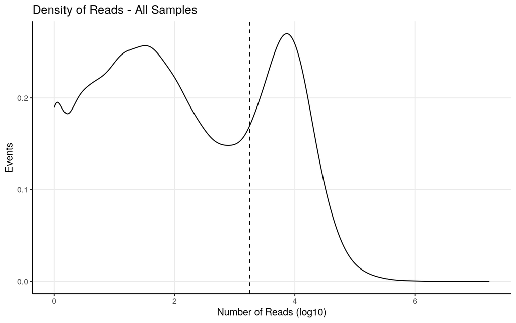

```r
alternew.U2G3AsLabEn <- log10(rowSums(read.counts[,1:2]))
alternew.U2G3AsLabEn <- as.data.frame(alternew.U2G3AsLabEn)

alternew.U2G3AsLabIn <- log10(rowSums(read.counts[,3:4]))
alternew.U2G3AsLabIn <- as.data.frame(alternew.U2G3AsLabIn)

alternew.U2G3AsNoLabEn <- log10(rowSums(read.counts[,5:6]))
alternew.U2G3AsNoLabEn <- as.data.frame(alternew.U2G3AsNoLabEn)

alternew.U2CtAsLabEn <- log10(rowSums(read.counts[,7:8]))
alternew.U2CtAsLabEn <- as.data.frame(alternew.U2CtAsLabEn)

alternew.HekG3AsLabEn <- log10(rowSums(read.counts[,9:10]))
alternew.HekG3AsLabEn <- as.data.frame(alternew.HekG3AsLabEn)

alternew.HekG3AsLabIn <- log10(rowSums(read.counts[,11:12]))
alternew.HekG3AsLabIn <- as.data.frame(alternew.HekG3AsLabIn)

alternew.HekG3AsNoLabEn <- log10(rowSums(read.counts[,13:14]))
alternew.HekG3AsNoLabEn <- as.data.frame(alternew.HekG3AsNoLabEn)

alternew.HekCtAsLabEn <- log10(rowSums(read.counts[,15:18]))
alternew.HekCtAsLabEn <- as.data.frame(alternew.HekCtAsLabEn)

alternew.HekG3UnLabEn <- log10(rowSums(read.counts[,19:20]))
alternew.HekG3UnLabEn <- as.data.frame(alternew.HekG3UnLabEn)

alternew.HekG3UnLabIn <- log10(rowSums(read.counts[,21:22]))
alternew.HekG3UnLabIn <- as.data.frame(alternew.HekG3UnLabIn)

alternew.HekG3UnNoLabEn <- log10(rowSums(read.counts[,23:24]))
alternew.HekG3UnNoLabEn <- as.data.frame(alternew.HekG3UnNoLabEn)

alternew.HekCtUnLabEn <- log10(rowSums(read.counts[,25:28]))
alternew.HekCtUnLabEn <- as.data.frame(alternew.HekCtUnLabEn)

alternew.HekG3SoLabEn <- log10(rowSums(read.counts[,29:30]))
alternew.HekG3SoLabEn <- as.data.frame(alternew.HekG3SoLabEn)

alternew.HekG3SoLabIn <- log10(rowSums(read.counts[,31:32]))
alternew.HekG3SoLabIn <- as.data.frame(alternew.HekG3SoLabIn)

alternew.HekG3SoNoLabEn <- log10(rowSums(read.counts[,33:34]))
alternew.HekG3SoNoLabEn <- as.data.frame(alternew.HekG3SoNoLabEn)

alternew.HekCtSoLabEn <- log10(rowSums(read.counts[,35:38]))
alternew.HekCtSoLabEn <- as.data.frame(alternew.HekCtSoLabEn)

alternew.HekG3T1LabEn <- log10(rowSums(read.counts[,39:41]))
alternew.HekG3T1LabEn <- as.data.frame(alternew.HekG3T1LabEn)

alternew.HekG3T1LabIn <- log10(rowSums(read.counts[,42:44]))
alternew.HekG3T1LabIn <- as.data.frame(alternew.HekG3T1LabIn)

alternew.HekG3T1NoLabEn <- log10(rowSums(read.counts[,45:47]))
alternew.HekG3T1NoLabEn <- as.data.frame(alternew.HekG3T1NoLabEn)

alternew.HekCtT1LabEn <- log10(rowSums(read.counts[,48:51]))
alternew.HekCtT1LabEn <- as.data.frame(alternew.HekCtT1LabEn)

alternew.HekG3T3LabEn <- log10(rowSums(read.counts[,52:53]))
alternew.HekG3T3LabEn <- as.data.frame(alternew.HekG3T3LabEn)

alternew.HekG3T3LabIn <- log10(rowSums(read.counts[,54:55]))
alternew.HekG3T3LabIn <- as.data.frame(alternew.HekG3T3LabIn)

alternew.HekG3T3NoLabEn <- log10(rowSums(read.counts[,56:57]))
alternew.HekG3T3NoLabEn <- as.data.frame(alternew.HekG3T3NoLabEn)

alternew.HekCtT3LabEn <- log10(rowSums(read.counts[,58:61]))
alternew.HekCtT3LabEn <- as.data.frame(alternew.HekCtT3LabEn)

alternew <- log10(rowSums(read.counts))
alternew <- as.data.frame(alternew)


ggplot(alternew, aes(x=alternew)) + geom_density() + theme_bw() + geom_vline(xintercept = 3.25, linetype = "dashed") + ylab("Events") + xlab("Number of Reads (log10)") +
  theme(axis.line = element_line(colour = "black"),
        panel.grid.minor = element_blank(),
        panel.border = element_blank(),
        panel.background = element_blank()) + ggtitle("Density of Reads - All Samples")
```

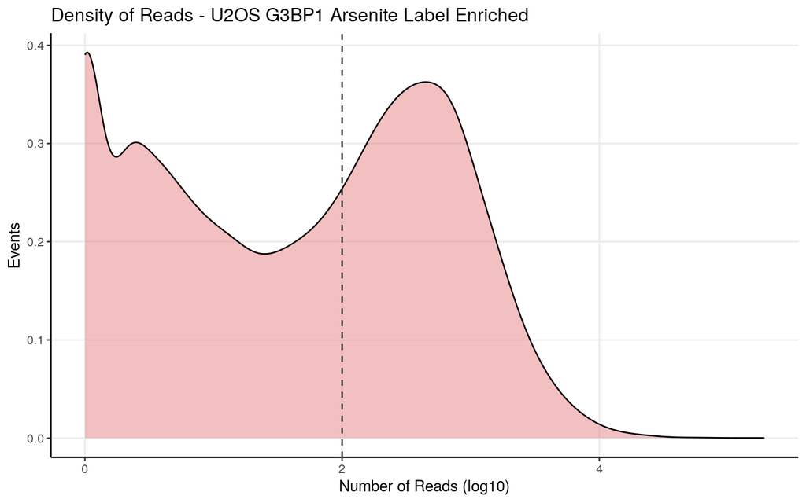

```r
# U2OS Cells
ggplot(alternew.U2G3AsLabEn, aes(x=alternew.U2G3AsLabEn)) + geom_density(fill="#e88184", alpha=0.5) + theme_bw() + geom_vline(xintercept = 2, linetype = "dashed") + ylab("Events") + xlab("Number of Reads (log10)") +
  theme(axis.line = element_line(colour = "black"),
        panel.grid.minor = element_blank(),
        panel.border = element_blank(),
        panel.background = element_blank()) + ggtitle("Density of Reads - U2OS G3BP1 Arsenite Label Enriched")
```

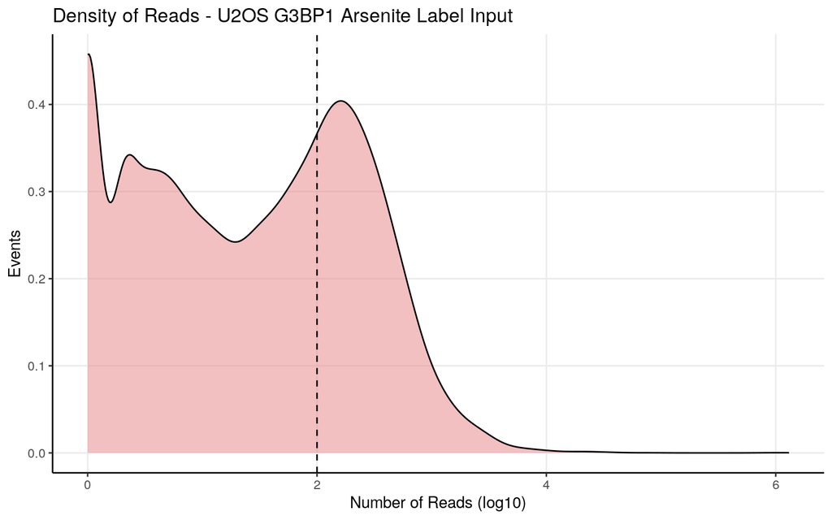

```r
ggplot(alternew.U2G3AsLabIn, aes(x=alternew.U2G3AsLabIn)) + geom_density(fill="#e88184", alpha=0.5) + theme_bw() + geom_vline(xintercept = 2, linetype = "dashed") + ylab("Events") + xlab("Number of Reads (log10)") +
  theme(axis.line = element_line(colour = "black"),
        panel.grid.minor = element_blank(),
        panel.border = element_blank(),
        panel.background = element_blank()) + ggtitle("Density of Reads - U2OS G3BP1 Arsenite Label Input")
```

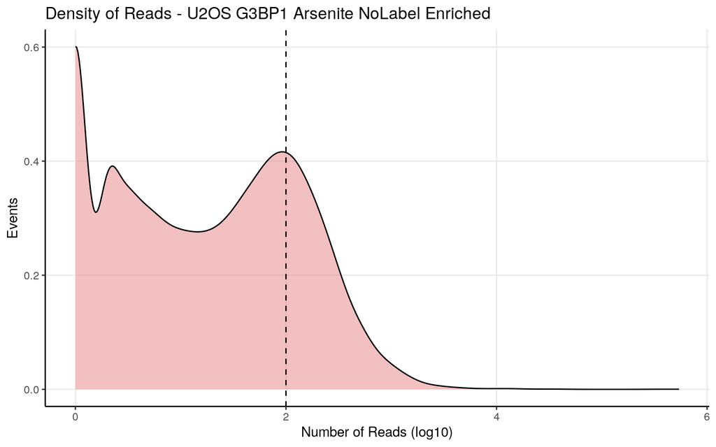

```r
ggplot(alternew.U2G3AsNoLabEn, aes(x=alternew.U2G3AsNoLabEn)) + geom_density(fill="#e88184", alpha=0.5) + theme_bw() + geom_vline(xintercept = 2, linetype = "dashed") + ylab("Events") + xlab("Number of Reads (log10)") +
  theme(axis.line = element_line(colour = "black"),
        panel.grid.minor = element_blank(),
        panel.border = element_blank(),
        panel.background = element_blank()) + ggtitle("Density of Reads - U2OS G3BP1 Arsenite NoLabel Enriched")
```

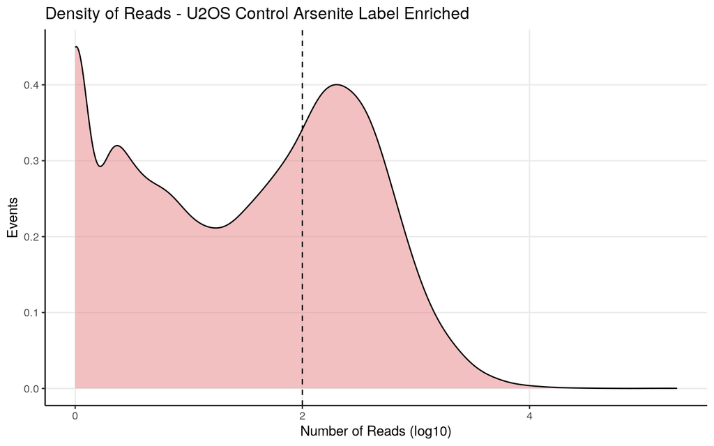

```r
ggplot(alternew.U2CtAsLabEn, aes(x=alternew.U2CtAsLabEn)) + geom_density(fill="#e88184", alpha=0.5) + theme_bw() + geom_vline(xintercept = 2, linetype = "dashed") + ylab("Events") + xlab("Number of Reads (log10)") +
  theme(axis.line = element_line(colour = "black"),
        panel.grid.minor = element_blank(),
        panel.border = element_blank(),
        panel.background = element_blank()) + ggtitle("Density of Reads - U2OS Control Arsenite Label Enriched")
```

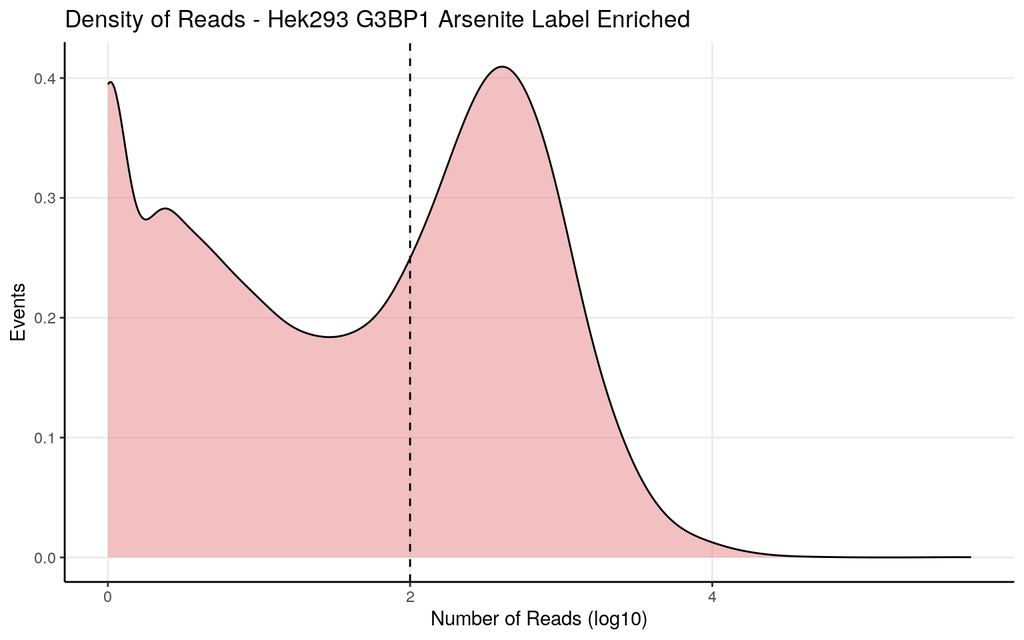

```r
# HEK ARSENITE STRESS

ggplot(alternew.HekG3AsLabEn, aes(x=alternew.HekG3AsLabEn)) + geom_density(fill="#e88184", alpha=0.5) + theme_bw() + geom_vline(xintercept = 2, linetype = "dashed") + ylab("Events") + xlab("Number of Reads (log10)") +
  theme(axis.line = element_line(colour = "black"),
        panel.grid.minor = element_blank(),
        panel.border = element_blank(),
        panel.background = element_blank()) + ggtitle("Density of Reads - Hek293 G3BP1 Arsenite Label Enriched")
```

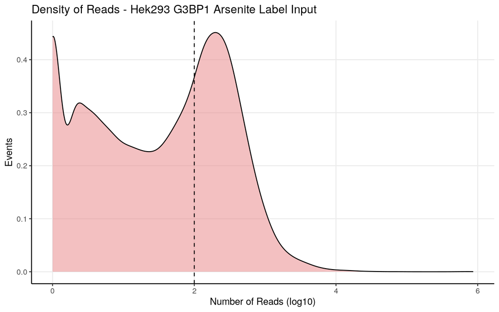

```r
ggplot(alternew.HekG3AsLabIn, aes(x=alternew.HekG3AsLabIn)) + geom_density(fill="#e88184", alpha=0.5) + theme_bw() + geom_vline(xintercept = 2, linetype = "dashed") + ylab("Events") + xlab("Number of Reads (log10)") +
  theme(axis.line = element_line(colour = "black"),
        panel.grid.minor = element_blank(),
        panel.border = element_blank(),
        panel.background = element_blank()) + ggtitle("Density of Reads - Hek293 G3BP1 Arsenite Label Input")
```

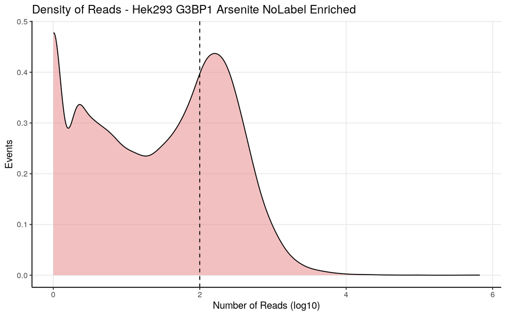

```r
ggplot(alternew.HekG3AsNoLabEn, aes(x=alternew.HekG3AsNoLabEn)) + geom_density(fill="#e88184", alpha=0.5) + theme_bw() + geom_vline(xintercept = 2, linetype = "dashed") + ylab("Events") + xlab("Number of Reads (log10)") +
  theme(axis.line = element_line(colour = "black"),
        panel.grid.minor = element_blank(),
        panel.border = element_blank(),
        panel.background = element_blank()) + ggtitle("Density of Reads - Hek293 G3BP1 Arsenite NoLabel Enriched")
```

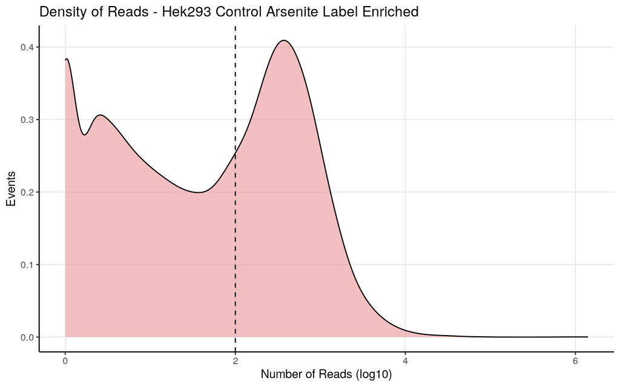

```r
ggplot(alternew.HekCtAsLabEn, aes(x=alternew.HekCtAsLabEn)) + geom_density(fill="#e88184", alpha=0.5) + theme_bw() + geom_vline(xintercept = 2, linetype = "dashed") + ylab("Events") + xlab("Number of Reads (log10)") +
  theme(axis.line = element_line(colour = "black"),
        panel.grid.minor = element_blank(),
        panel.border = element_blank(),
        panel.background = element_blank()) + ggtitle("Density of Reads - Hek293 Control Arsenite Label Enriched")
```

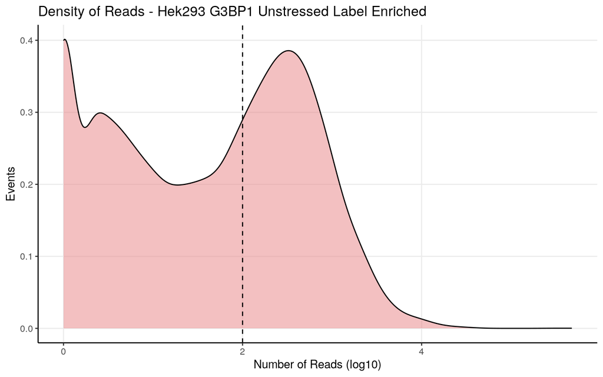

```r
# HEK NO STRESS

ggplot(alternew.HekG3UnLabEn, aes(x=alternew.HekG3UnLabEn)) + geom_density(fill="#e88184", alpha=0.5) + theme_bw() + geom_vline(xintercept = 2, linetype = "dashed") + ylab("Events") + xlab("Number of Reads (log10)") +
  theme(axis.line = element_line(colour = "black"),
        panel.grid.minor = element_blank(),
        panel.border = element_blank(),
        panel.background = element_blank()) + ggtitle("Density of Reads - Hek293 G3BP1 Unstressed Label Enriched")
```

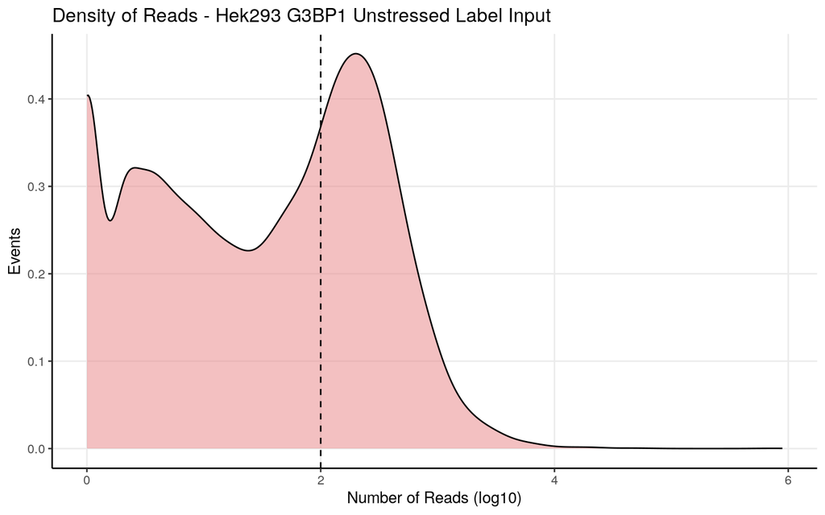

```r
ggplot(alternew.HekG3UnLabIn, aes(x=alternew.HekG3UnLabIn)) + geom_density(fill="#e88184", alpha=0.5) + theme_bw() + geom_vline(xintercept = 2, linetype = "dashed") + ylab("Events") + xlab("Number of Reads (log10)") +
  theme(axis.line = element_line(colour = "black"),
        panel.grid.minor = element_blank(),
        panel.border = element_blank(),
        panel.background = element_blank()) + ggtitle("Density of Reads - Hek293 G3BP1 Unstressed Label Input")
```

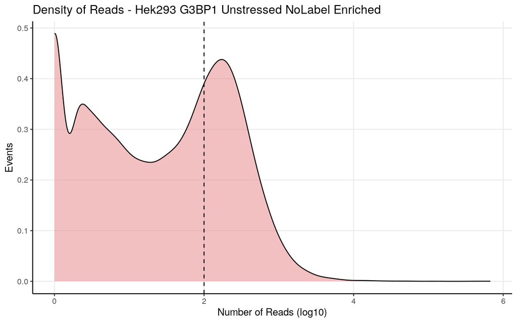

```r
ggplot(alternew.HekG3UnNoLabEn, aes(x=alternew.HekG3UnNoLabEn)) + geom_density(fill="#e88184", alpha=0.5) + theme_bw() + geom_vline(xintercept = 2, linetype = "dashed") + ylab("Events") + xlab("Number of Reads (log10)") +
  theme(axis.line = element_line(colour = "black"),
        panel.grid.minor = element_blank(),
        panel.border = element_blank(),
        panel.background = element_blank()) + ggtitle("Density of Reads - Hek293 G3BP1 Unstressed NoLabel Enriched")
```

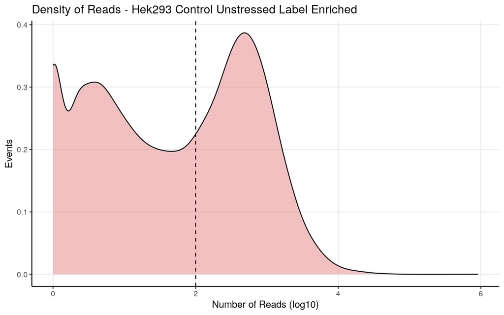

```r
ggplot(alternew.HekCtUnLabEn, aes(x=alternew.HekCtUnLabEn)) + geom_density(fill="#e88184", alpha=0.5) + theme_bw() + geom_vline(xintercept = 2, linetype = "dashed") + ylab("Events") + xlab("Number of Reads (log10)") +
  theme(axis.line = element_line(colour = "black"),
        panel.grid.minor = element_blank(),
        panel.border = element_blank(),
        panel.background = element_blank()) + ggtitle("Density of Reads - Hek293 Control Unstressed Label Enriched")
```

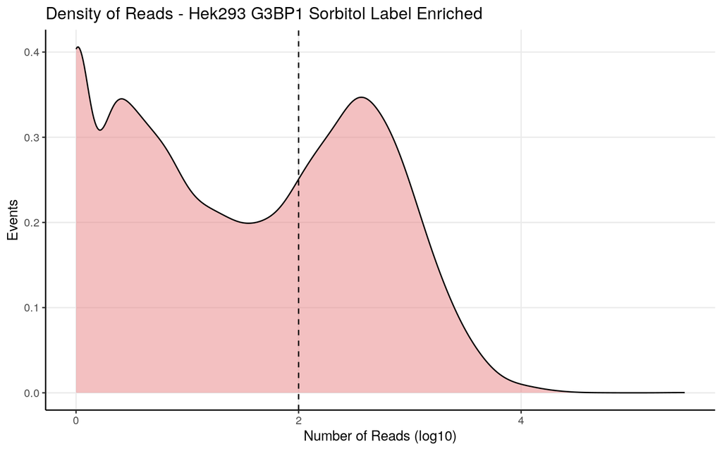

```r
# HEK SORBITOL

ggplot(alternew.HekG3SoLabEn, aes(x=alternew.HekG3SoLabEn)) + geom_density(fill="#e88184", alpha=0.5) + theme_bw() + geom_vline(xintercept = 2, linetype = "dashed") + ylab("Events") + xlab("Number of Reads (log10)") +
  theme(axis.line = element_line(colour = "black"),
        panel.grid.minor = element_blank(),
        panel.border = element_blank(),
        panel.background = element_blank()) + ggtitle("Density of Reads - Hek293 G3BP1 Sorbitol Label Enriched")
```

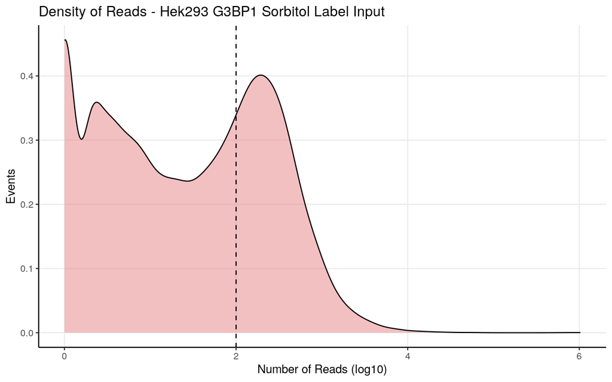

```r
ggplot(alternew.HekG3SoLabIn, aes(x=alternew.HekG3SoLabIn)) + geom_density(fill="#e88184", alpha=0.5) + theme_bw() + geom_vline(xintercept = 2, linetype = "dashed") + ylab("Events") + xlab("Number of Reads (log10)") +
  theme(axis.line = element_line(colour = "black"),
        panel.grid.minor = element_blank(),
        panel.border = element_blank(),
        panel.background = element_blank()) + ggtitle("Density of Reads - Hek293 G3BP1 Sorbitol Label Input")
```

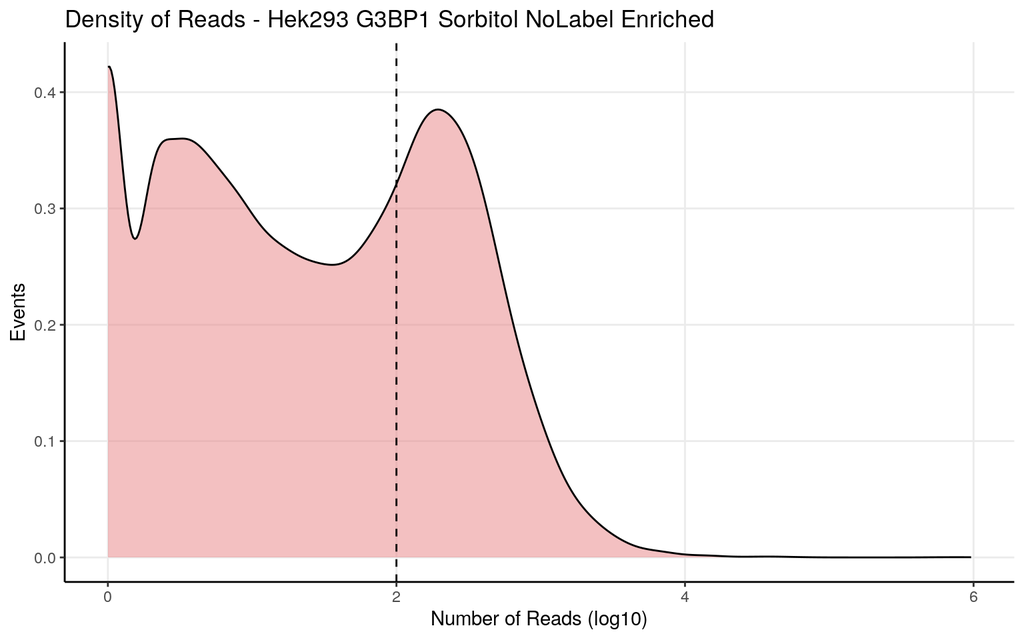

```r
ggplot(alternew.HekG3SoNoLabEn, aes(x=alternew.HekG3SoNoLabEn)) + geom_density(fill="#e88184", alpha=0.5) + theme_bw() + geom_vline(xintercept = 2, linetype = "dashed") + ylab("Events") + xlab("Number of Reads (log10)") +
  theme(axis.line = element_line(colour = "black"),
        panel.grid.minor = element_blank(),
        panel.border = element_blank(),
        panel.background = element_blank()) + ggtitle("Density of Reads - Hek293 G3BP1 Sorbitol NoLabel Enriched")
```

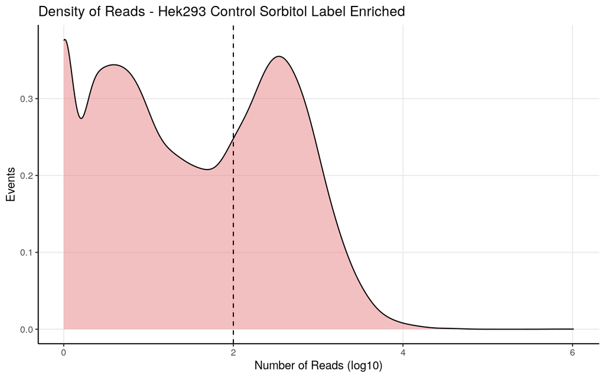

```r
ggplot(alternew.HekCtSoLabEn, aes(x=alternew.HekCtSoLabEn)) + geom_density(fill="#e88184", alpha=0.5) + theme_bw() + geom_vline(xintercept = 2, linetype = "dashed") + ylab("Events") + xlab("Number of Reads (log10)") +
  theme(axis.line = element_line(colour = "black"),
        panel.grid.minor = element_blank(),
        panel.border = element_blank(),
        panel.background = element_blank()) + ggtitle("Density of Reads - Hek293 Control Sorbitol Label Enriched")
```

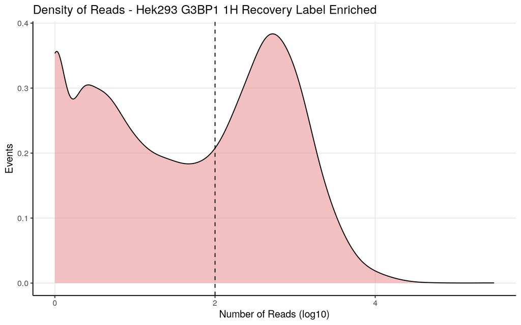

```r
# HEK 1H RECOVERY

ggplot(alternew.HekG3T1LabEn, aes(x=alternew.HekG3T1LabEn)) + geom_density(fill="#e88184", alpha=0.5) + theme_bw() + geom_vline(xintercept = 2, linetype = "dashed") + ylab("Events") + xlab("Number of Reads (log10)") +
  theme(axis.line = element_line(colour = "black"),
        panel.grid.minor = element_blank(),
        panel.border = element_blank(),
        panel.background = element_blank()) + ggtitle("Density of Reads - Hek293 G3BP1 1H Recovery Label Enriched")
```

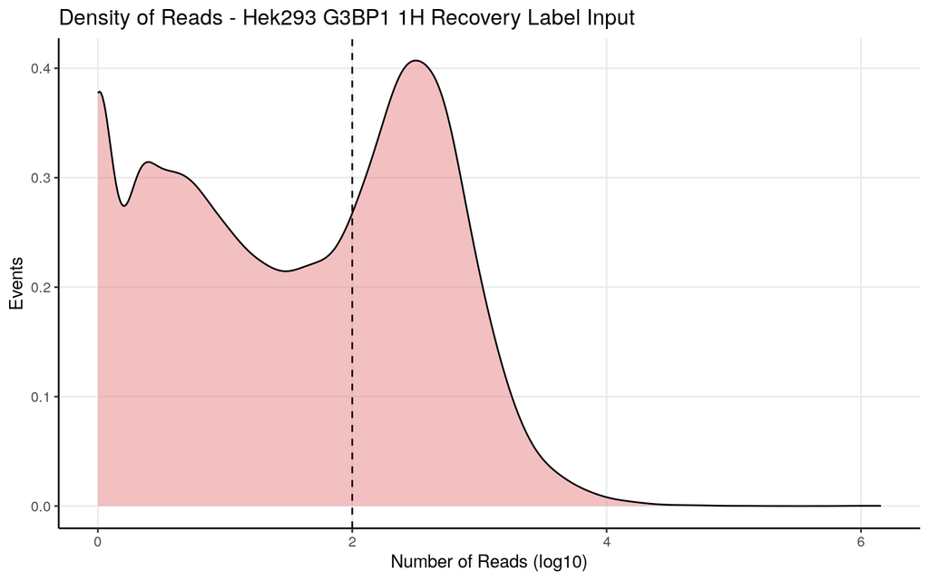

```r
ggplot(alternew.HekG3T1LabIn, aes(x=alternew.HekG3T1LabIn)) + geom_density(fill="#e88184", alpha=0.5) + theme_bw() + geom_vline(xintercept = 2, linetype = "dashed") + ylab("Events") + xlab("Number of Reads (log10)") +
  theme(axis.line = element_line(colour = "black"),
        panel.grid.minor = element_blank(),
        panel.border = element_blank(),
        panel.background = element_blank()) + ggtitle("Density of Reads - Hek293 G3BP1 1H Recovery Label Input")
```

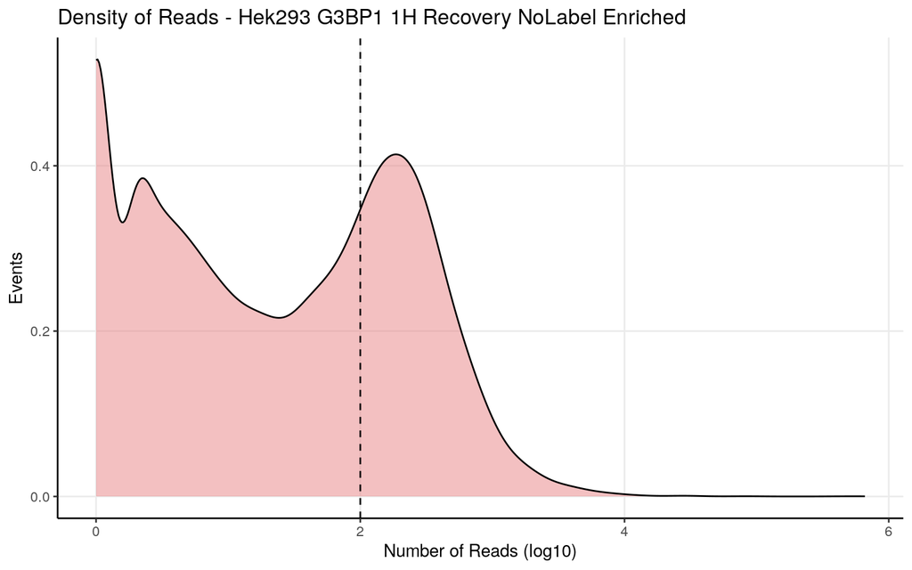

```r
ggplot(alternew.HekG3T1NoLabEn, aes(x=alternew.HekG3T1NoLabEn)) + geom_density(fill="#e88184", alpha=0.5) + theme_bw() + geom_vline(xintercept = 2, linetype = "dashed") + ylab("Events") + xlab("Number of Reads (log10)") +
  theme(axis.line = element_line(colour = "black"),
        panel.grid.minor = element_blank(),
        panel.border = element_blank(),
        panel.background = element_blank()) + ggtitle("Density of Reads - Hek293 G3BP1 1H Recovery NoLabel Enriched")
```

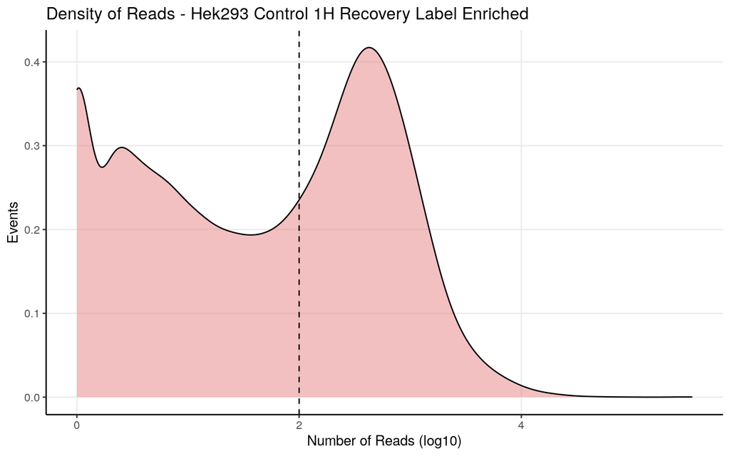

```r
ggplot(alternew.HekCtT1LabEn, aes(x=alternew.HekCtT1LabEn)) + geom_density(fill="#e88184", alpha=0.5) + theme_bw() + geom_vline(xintercept = 2, linetype = "dashed") + ylab("Events") + xlab("Number of Reads (log10)") +
  theme(axis.line = element_line(colour = "black"),
        panel.grid.minor = element_blank(),
        panel.border = element_blank(),
        panel.background = element_blank()) + ggtitle("Density of Reads - Hek293 Control 1H Recovery Label Enriched")
```

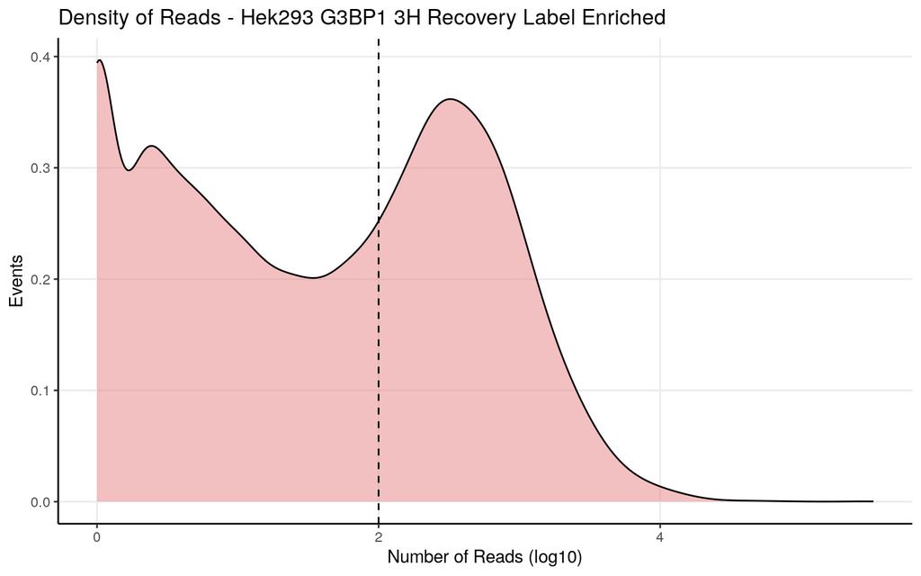

```r
# HEK 3H RECOVERY

ggplot(alternew.HekG3T3LabEn, aes(x=alternew.HekG3T3LabEn)) + geom_density(fill="#e88184", alpha=0.5) + theme_bw() + geom_vline(xintercept = 2, linetype = "dashed") + ylab("Events") + xlab("Number of Reads (log10)") +
  theme(axis.line = element_line(colour = "black"),
        panel.grid.minor = element_blank(),
        panel.border = element_blank(),
        panel.background = element_blank()) + ggtitle("Density of Reads - Hek293 G3BP1 3H Recovery Label Enriched")
```

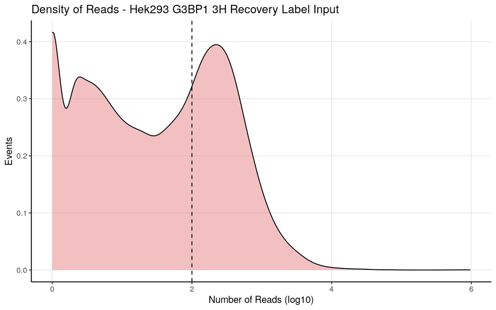

```r
ggplot(alternew.HekG3T3LabIn, aes(x=alternew.HekG3T3LabIn)) + geom_density(fill="#e88184", alpha=0.5) + theme_bw() + geom_vline(xintercept = 2, linetype = "dashed") + ylab("Events") + xlab("Number of Reads (log10)") +
  theme(axis.line = element_line(colour = "black"),
        panel.grid.minor = element_blank(),
        panel.border = element_blank(),
        panel.background = element_blank()) + ggtitle("Density of Reads - Hek293 G3BP1 3H Recovery Label Input")
```

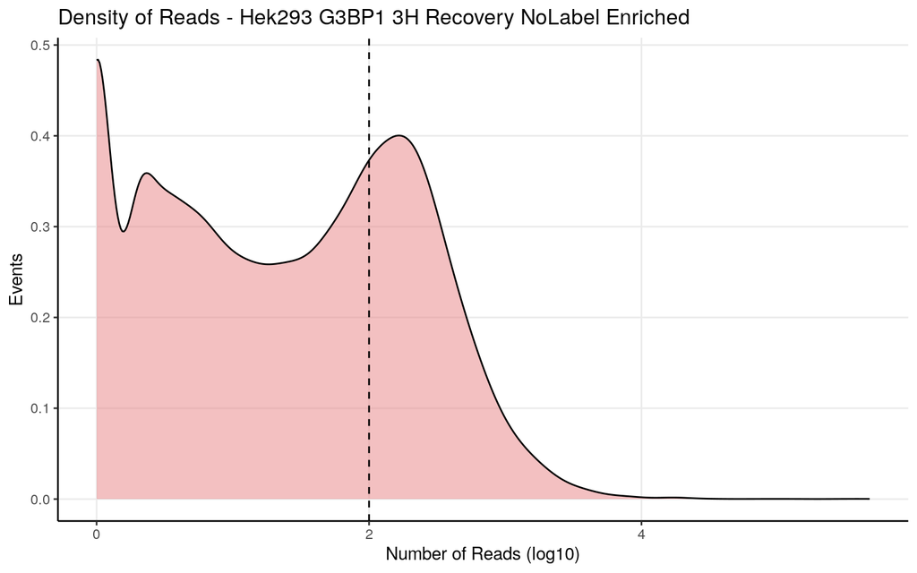

```r
ggplot(alternew.HekG3T3NoLabEn, aes(x=alternew.HekG3T3NoLabEn)) + geom_density(fill="#e88184", alpha=0.5) + theme_bw() + geom_vline(xintercept = 2, linetype = "dashed") + ylab("Events") + xlab("Number of Reads (log10)") +
  theme(axis.line = element_line(colour = "black"),
        panel.grid.minor = element_blank(),
        panel.border = element_blank(),
        panel.background = element_blank()) + ggtitle("Density of Reads - Hek293 G3BP1 3H Recovery NoLabel Enriched")
```

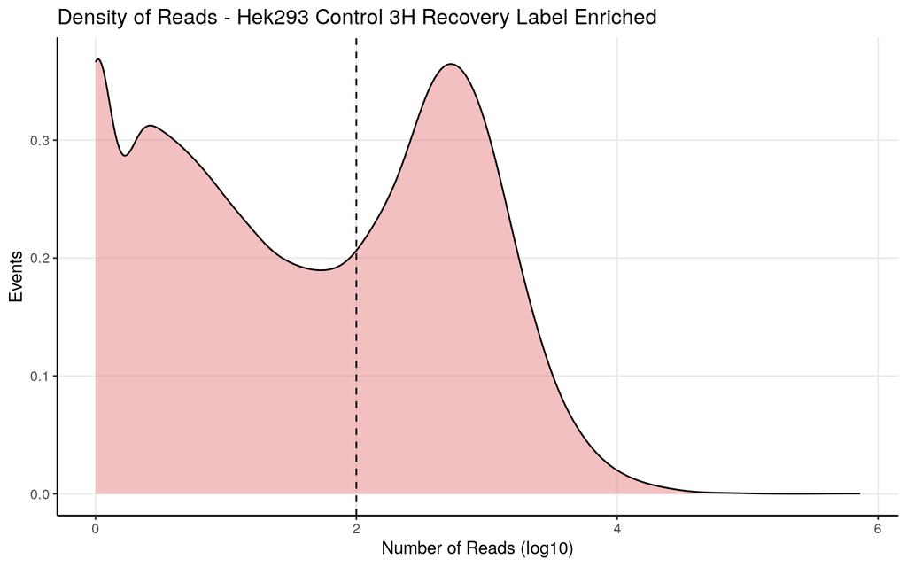

```r
ggplot(alternew.HekCtT3LabEn, aes(x=alternew.HekCtT3LabEn)) + geom_density(fill="#e88184", alpha=0.5) + theme_bw() + geom_vline(xintercept = 2, linetype = "dashed") + ylab("Events") + xlab("Number of Reads (log10)") +
  theme(axis.line = element_line(colour = "black"),
        panel.grid.minor = element_blank(),
        panel.border = element_blank(),
        panel.background = element_blank()) + ggtitle("Density of Reads - Hek293 Control 3H Recovery Label Enriched")
```

By seeing the shape of the graph, we can see where we should cut. We have a **binomial distribution** (low reads and noise vs actual biological meaningful reads). The ideal place to cut them is right before the wedge.

### *After Filtration*

This time, I considered that it was more correct to filter all samples together.

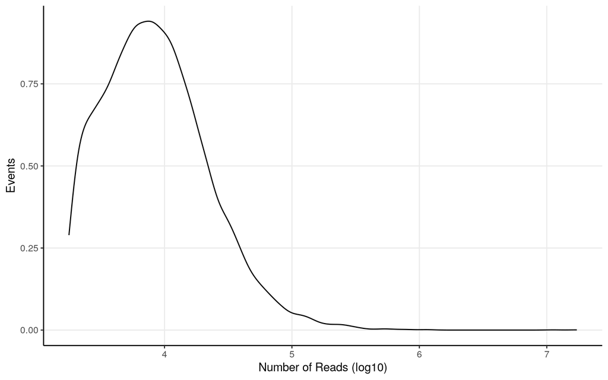

```r
filterednew <- subset(read.counts, alternew>3.25)
MitoGenes <- fread("~/MitoGenes.txt", header = FALSE)[[1]]

#after cutting, its a good idea to visualize again
falternew <- log10(rowSums(filterednew))
falternew <- as.data.frame(falternew)
ggplot(falternew, aes(x=falternew)) + geom_density() + theme_bw() + ylab("Events") + xlab("Number of Reads (log10)") +
  theme(axis.line = element_line(colour = "black"),
        panel.grid.minor = element_blank(),
        panel.border = element_blank(),
        panel.background = element_blank())
```

```r
#lets save the genes which we maintain
impgenes <- c(row.names(falternew), MitoGenes)


#Now we need to select only the rows which have those genes.
finaltable <- read.counts[row.names(read.counts)%in%impgenes,]
```

## Matrices

Good! Now we can proceed by designing our matrices.

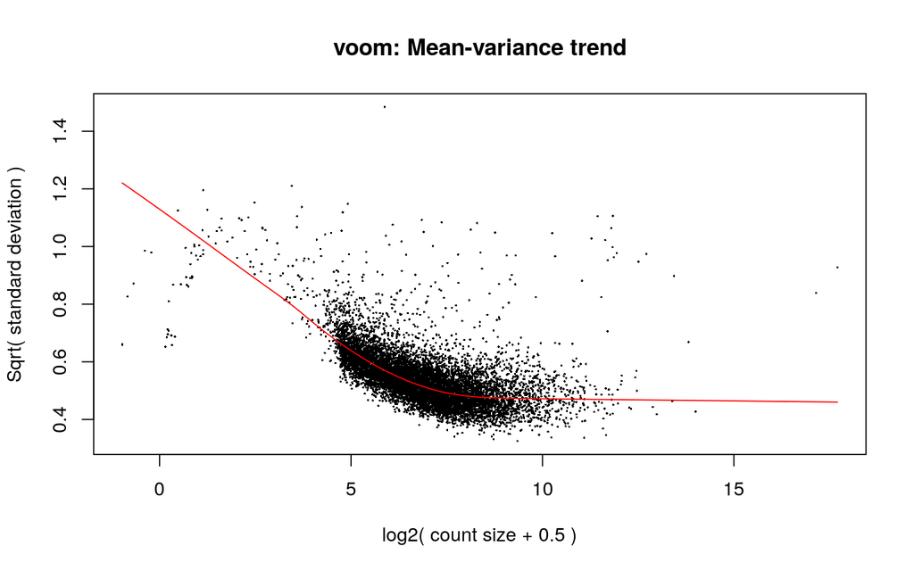

```r
#To be able to use Voom, we must first convert our read count table into a special DGE object.
D0 <- DGEList(finaltable)


#Then we calculate the normalization factors for these new generated data frames
#Bear in mind this step calculates the normalization factors, but does not normalize itself.
D0 <- calcNormFactors(D0)


#Lets create a dataframe with all of the medatata information
CellType <- c(rep("U2",8), rep("Hek",53))
ProbeType <- c(rep("G3",6), rep("Ct",2),rep("G3",6), rep("Ct",4),rep("G3",6), rep("Ct",4),rep("G3",6), rep("Ct",4),rep("G3",9), rep("Ct",4),rep("G3",6), rep("Ct",4))
StressType <- c(rep("Arsenite",18),rep("Unstressed",10),rep("Sorbitol",10),rep("H1",13),rep("H3",10))
LabType <- c(rep("Yes",4),rep("No",2),rep("Yes",2), #U2
             rep("Yes",4),rep("No",2),rep("Yes",4), #HekAs
             rep("Yes",4),rep("No",2),rep("Yes",4), #HekUn
             rep("Yes",4),rep("No",2),rep("Yes",4), #HekSo
             rep("Yes",6),rep("No",3),rep("Yes",4),
             rep("Yes",4),rep("No",2),rep("Yes",4))
SampleType <- c(rep("Enriched",2),rep("Input",2),rep("Enriched",4), #U2
             rep("Enriched",2),rep("Input",2),rep("Enriched",6), #HekAs
             rep("Enriched",2),rep("Input",2),rep("Enriched",6), #HekUn
             rep("Enriched",2),rep("Input",2),rep("Enriched",6), #HekSo
             rep("Enriched",3),rep("Input",3),rep("Enriched",7),
             rep("Enriched",2),rep("Input",2),rep("Enriched",6))
Biotype <- c(rep("SG",2),rep("WC",4),rep("Vec",2), #U2
             rep("SG",2),rep("WC",4),rep("Vec",4), #HekAs
             rep("SG",2),rep("WC",4),rep("Vec",4), #HekUn
             rep("SG",2),rep("WC",4),rep("Vec",4), #HekSo
             rep("SG",3),rep("WC",6),rep("Vec",4),
             rep("SG",2),rep("WC",4),rep("Vec",4))


metadata <- data.frame(Cell=CellType, Stress=StressType, Bio=Biotype)


#Now we do the matrixes

mm <- model.matrix(~0+CellType+StressType+Biotype)


#and now we normalize. This step also turns our counts into log2-counts per million.
#The object with all simple
y <- voom(D0, mm, plot = T)
```

## Normalisation

For normalisation I convert the read counts into log2CPMs. Its a good way to visualize how the reads are.

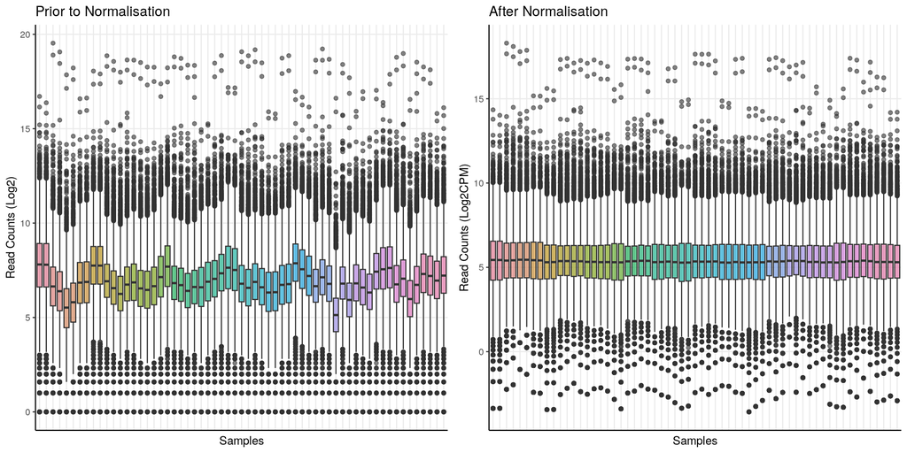

```r
custom_palette <- qualitative_hcl(24, palette = "Dark3")

dfforboxy <- finaltable
orderforplots <- SampleColouring
colouring <- data.frame(Sample=colnames(dfforboxy), Types=orderforplots)
dfforboxy <- reshape2::melt(dfforboxy)
colnames(dfforboxy) <- c("Sample", "Expression")
dfforboxy <- merge(dfforboxy, colouring, by="Sample")
# Convert 'Types' to factor with custom order
dfforboxy$Types <- factor(dfforboxy$Types, levels = unique(SampleColouring))

prenorm <- ggplot(dfforboxy, aes(x=Sample, y=(log2(Expression+1)), fill=Types)) + geom_boxplot(alpha=0.6) + theme_bw() + ylab("Read Counts (Log2)") + xlab("Samples") + scale_fill_manual(name = "Sample Type", values = custom_palette, labels=c(unique(orderforplots))) +
  theme(axis.line = element_line(colour = "black"),
        panel.grid.minor = element_blank(),
        panel.border = element_blank(),
        panel.background = element_blank(),
        axis.text.x=element_blank(),
        axis.ticks.x=element_blank(),
        legend.position = "None") + ggtitle("Prior to Normalisation")

#Using the Standard Matrix

dfforboxy <- y$E
dfforboxy <- reshape2::melt(dfforboxy)
dfforboxy <- dfforboxy[,-1]
colnames(dfforboxy) <- c("Sample", "Expression")
dfforboxy <- merge(dfforboxy, colouring, by="Sample")
# Convert 'Types' to factor with custom order
dfforboxy$Types <- factor(dfforboxy$Types, levels = unique(SampleColouring))
postnorm <- ggplot(dfforboxy, aes(x=Sample, y=Expression, fill=Types)) + geom_boxplot(alpha=0.6) + theme_bw() + ylab("Read Counts (Log2CPM)") + xlab("Samples") + scale_fill_manual(name = "Sample Type", values = custom_palette, labels=c(unique(orderforplots))) +
  theme(axis.line = element_line(colour = "black"),
        panel.grid.minor = element_blank(),
        panel.border = element_blank(),
        panel.background = element_blank(),
        axis.text.x=element_blank(),
        axis.ticks.x=element_blank(),
        legend.position = "None") + ggtitle("After Normalisation")

ggarrange(prenorm, postnorm, nrow=1)
```

In this case, from the boxplots, we can see that there no samples which can be considered outliers.